# Homework 12

Małgorzata Pujszo

Thursday, January 07, 2016

We would like to find out if there is any relation between thich and soil variables in the dataset spdata.

Firstly, let’s look at our dataset.

```r
library(nlme)
library(geoR)
library(ggplot2)
library(knitr)
spdata <- read.table("http://www.ats.ucla.edu/stat/r/faq/thick.csv", header = T, sep = ",")
head(spdata)
```

```
##   X east north thick     soil dummy
## 1 1  0.7  59.6  34.1 3.635764     1
## 2 2  2.1  82.7  42.2 3.502083     1
## 3 3  4.7  75.1  39.5 3.946545     1
## 4 4  4.8  52.8  34.3 2.941715     1
## 5 5  5.9  67.1  37.0 3.866264     1
## 6 6  6.0  35.7  35.9 3.018548     1
```

I began with a simple model just taking into account those two interesting variables.

```r
model1 <- lme(thick ~ soil, data=spdata, random= ~1|dummy, method="ML")
summary(model1)
```

```
## Linear mixed-effects model fit by maximum likelihood
##  Data: spdata
##        AIC      BIC    logLik
##   342.3182 351.5881 -167.1591
##
## Random effects:
##  Formula: ~1 | dummy
##          (Intercept) Residual
## StdDev: 4.815352e-05 2.247569
##
## Fixed effects: thick ~ soil
##                Value Std.Error DF   t-value p-value
## (Intercept) 31.94203 3.1569891 73 10.117878  0.0000
## soil         2.25521 0.8655887 73  2.605407  0.0111
##  Correlation:
##      (Intr)
## soil -0.997
##
## Standardized Within-Group Residuals:
##         Min          Q1         Med          Q3         Max
## -2.68798974 -0.53279498  0.03896491  0.66007203  2.20612991
##
## Number of Observations: 75
## Number of Groups: 1
```

Since the p-value for soil is low, it suggest that there is a relation between those variables. I plotted them together with linear fit.

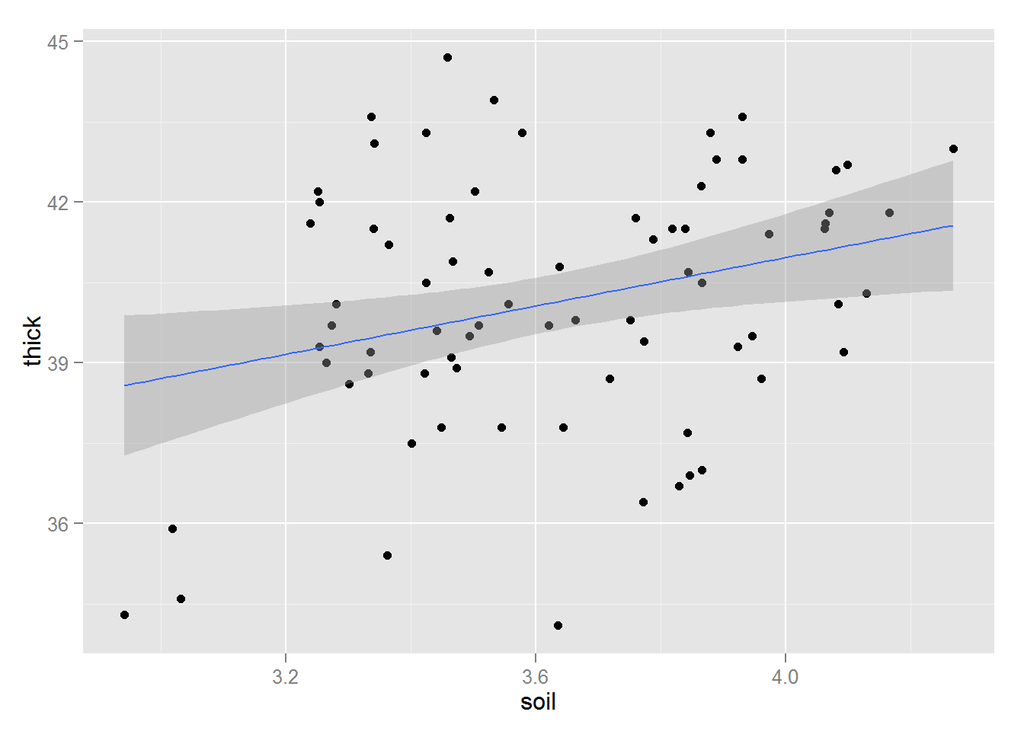

```r
ggplot(spdata, aes(x=soil, y=thick)) + geom_point()+stat_smooth(method="lm")
```

In the plot I don’t see clear relation. Since in the dataset we have also information about location of measurement (east and north variables), it may be a good idea to take them into account.

Let’s first look at variograms. (First variogram is showing all information, second is cut in order to show the line.)

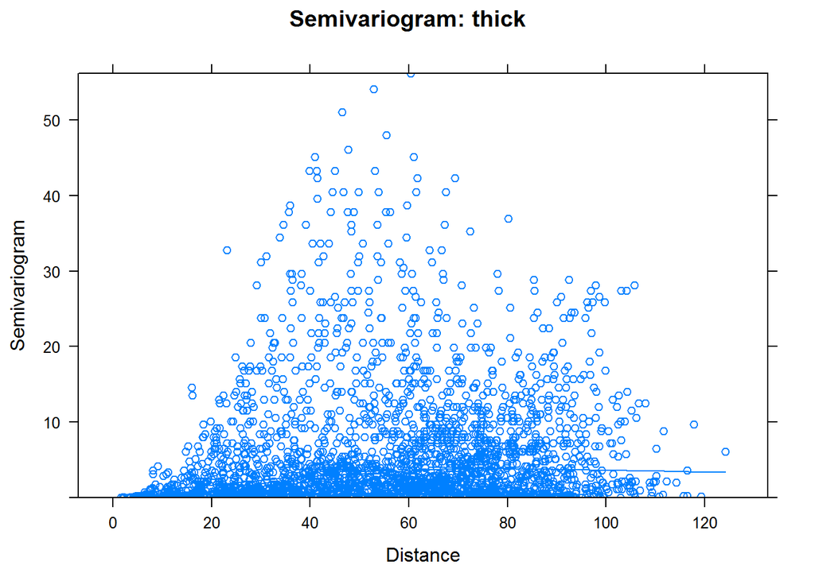

```r
plot(Variogram(spdata$thick, dist(spdata[,2:3])),
  xlab="Distance", main="Semivariogram: thick")
```

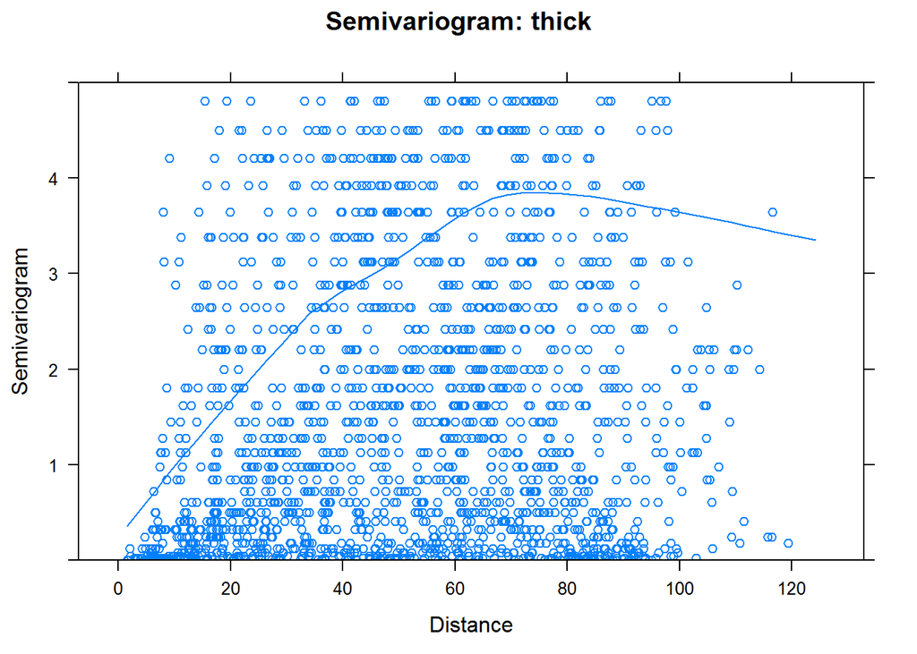

```r
plot(Variogram(spdata$thick, dist(spdata[,2:3])),
  xlab="Distance", ylim=c(0, 5), main="Semivariogram: thick")
```

Variograms suggest that distance between measurement may be important. We can see that measurements which were taken closely to each other are the most similar and around distance 60-70 measurements’ differences are the largest.

I would like to take into account spatial structure but I need to find out which spatial correlation structure I should use. In order to check it, let’s firstly plot variogram together with different fits.

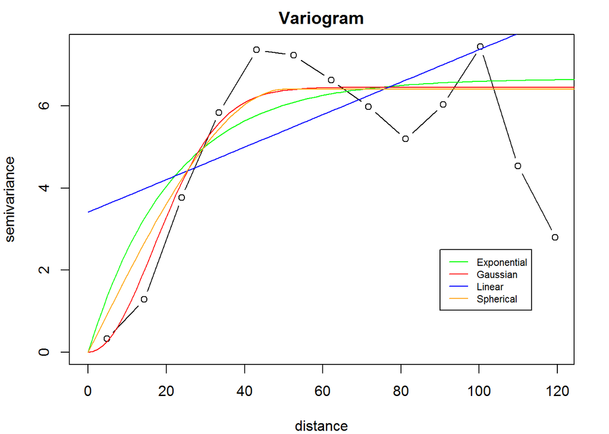

```r
v1 <- variog(coords = spdata[,2:3], data = spdata$thick, message=FALSE)
vexp <- variofit(cov.model="exponential", vario=v1, ini.cov.pars=c(10, 10), message=FALSE )
vgaus <- variofit(cov.model="gaussian", vario=v1, ini.cov.pars=c(10, 10), message=FALSE )
vlin <- variofit(cov.model="linear", vario=v1, ini.cov.pars=c(10, 10), message=FALSE )
vsph <- variofit(cov.model="spherical", vario=v1, ini.cov.pars=c(10, 10), message=FALSE )

par(mar=c(4, 4, 2, 2))
plot(v1, type = "b", main="Variogram")
lines.variomodel(vexp, col="green")
lines.variomodel(vgaus, col="red")
lines.variomodel(vlin, col="blue")
lines.variomodel(vsph, col="orange")
legend(90,2.5, c("Exponential", "Gaussian", "Linear", "Spherical"), lty=c(1,1,1,1,1), col=c("green", "red", "blue", "orange"), cex=0.7)
```

The best fit seem to have Gaussian structure. But let’s build those models and see which fits best (considering AIC, BIC and LogLik criteria).

```r
aic.models <- vector(length=5)
bic.models <- vector(length=5)
loglik.models <- vector(length=5)
names <- vector(length=5)

model2 <- lme(thick ~ soil, data=spdata, correlation = corGaus(form = ~ east + north), random= ~1|dummy, method="ML")
model3 <- lme(thick ~ soil, data=spdata, correlation = corSpher(form = ~ east + north), random= ~1|dummy, method="ML")
model4 <- lme(thick ~ soil, data=spdata, correlation = corLin(form = ~ east + north), random= ~1|dummy, method="ML")
model5 <- lme(thick ~ soil, data=spdata, correlation = corExp(form = ~ east + north), random= ~1|dummy, method="ML")

models <- list(model1, model2, model3, model4, model5)

for (i in 1:5) {
  model <- models[[i]]
  aic.models[i] <- summary(model)$AIC
  bic.models[i] <- summary(model)$BIC
  loglik.models[i] <- summary(model)$logLik
  names[i] <- paste0("model", i)
}
kable(cbind(names, aic.models))
```

| names | aic.models |
| --- | --- |
| model1 | 342.318184415026 |
| model2 | 91.5073269448172 |
| model3 | 344.318319956461 |
| model4 | 167.469658269906 |
| model5 | 169.104061124898 |

```r
kable(cbind(names, bic.models))
```

| names | bic.models |
| --- | --- |
| model1 | 351.588136869171 |
| model2 | 103.094767512499 |
| model3 | 355.905760524142 |
| model4 | 179.057098837587 |
| model5 | 180.691501692579 |

```r
kable(cbind(names, loglik.models))
```

| names | loglik.models |
| --- | --- |
| model1 | -167.159092207513 |
| model2 | -40.7536634724086 |
| model3 | -167.15915997823 |
| model4 | -78.7348291349529 |
| model5 | -79.5520305624489 |

All three criteria gives the same answer that model2 (with Gaussian correlation structure is the best fit). Consequently, I used it as a final model.

```r
summary(model2)
```

```
## Linear mixed-effects model fit by maximum likelihood
##  Data: spdata
##        AIC      BIC    logLik
##   91.50733 103.0948 -40.75366
##
## Random effects:
##  Formula: ~1 | dummy
##          (Intercept) Residual
## StdDev: 7.497427e-05 2.088388
##
## Correlation Structure: Gaussian spatial correlation
##  Formula: ~east + north | dummy
##  Parameter estimate(s):
##    range
## 20.43726
## Fixed effects: thick ~ soil
##                Value Std.Error DF  t-value p-value
## (Intercept) 40.32797 0.5877698 73 68.61184  0.0000
## soil         0.00348 0.0160363 73  0.21693  0.8289
##  Correlation:
##      (Intr)
## soil -0.102
##
## Standardized Within-Group Residuals:
##        Min         Q1        Med         Q3        Max
## -2.9882458 -0.7133759 -0.1146242  0.6745680  2.0877341
##
## Number of Observations: 75
## Number of Groups: 1
```

Large p-value of soil variable indicates that there is no relation between thich and soil. This example shows that without taking into account spatial structure of measurements we would wrongly conclude that there is a relation between interesting variables whereas in fact there isn’t any.